# Instituto Tecnologico de Aguascalientes

# Departamento: Sistemas y Computacion

# carrera: Ingenieria en ciberseguridad

## Materia: Estructura de datos

## Maestro:Dr. Fransisco Javier Luna Rosas

## Alumno: Mayrin Ximena Oliva Reyes

### Semestre: Agosto_Diciembre del 2026

## Estructuras de Datos Estáticas Lineales

### Las estructuras de datos lineales son aquilles en las que los elementos se organizan uno después de otro, formando una secuencia

## ¿Qué es una Matriz Estática?

### Una matriz estática es una estructura de datos que tiene un número fijo de filas y columnas, definidas desde el momento que se crean.

## Imágen Digital

### Digitalmente, una imágen puede representarse como una matriz especialmente cuando hablamos de procesamiento de imágenes.

# Practica No.6

### En esta practica implementarmos un programa en Python para abrir una imagen digital llamada mapache.png. La convertiremos en una matriz de pixeles usando numpy y despues mostraremos la matriz de la imagen. En la practica tambien cargararemos un archivo mapache.csv y lo convertiremos en un DataFrame, posteriormente convertiremos el DataFrame en una imagen de 256 x 256 pixeles

# Paso 1: Importar las librerias necesarias

### Nota 1: Para los siguientes ejemplos utilizaremos la biblioteca Pillow. Consultar documentacion en:

### URL: imagenes en python (Pillow, 2026) https://pillow.readthedocs.io/en/stable/ (Ultimo acceso Septiembre de 2026)

```python
import os
import pandas as pd
import numpy as np
import matplotlib.pyplot as plt
from PIL import Image, ImageFilter
```

# Paso 2: Especificamos la ruta y cargamos la imagen

### Nota: en la linea de os.chidr, cambiar la ruta de donde se encuentra la imagen, asi como en Image.open si la imagen tiene un nombre o tipo de imagen diferente

```
[[136 126 123 ... 180 187 170]
 [104 115 121 ... 176 181 183]
 [104 118 127 ... 175 178 193]
 ...
 [139 140 140 ... 118 115 139]
 [139 140 140 ... 124 122 142]
 [138 139 139 ... 120 105 131]]
```

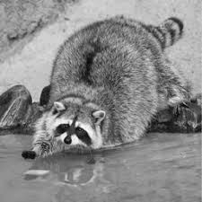

```python
os.chdir(r"C:\Users\mayri\OneDrive\Escritorio\Estructura-de-Datos")

with Image.open("mapache.png", 'r') as img:
    pixel_array = np.array(img, dtype = "uint8")

print(pixel_array)
img
```

## Paso 3: Cargamos la imagen desde un archivo *.csv. Cargamos el archivo en formato csv que contiene la representacion ed pixeles de la imagen mapache.jpeg. Escala 0 (negro) -255 (blanco)

```python
dt_mapache = pd.read_csv("mapache.csv", sep=";", decimal=".", header=None, index_col=None)
dt_mapache
```

|  | 0 | 1 | 2 | 3 | 4 | 5 | 6 | 7 | 8 | 9 | ... | 215 | 216 | 217 | 218 | 219 | 220 | 221 | 222 | 223 | 224 |
| --- | --- | --- | --- | --- | --- | --- | --- | --- | --- | --- | --- | --- | --- | --- | --- | --- | --- | --- | --- | --- | --- |
| 0 | 136 | 126 | 123 | 129 | 129 | 121 | 121 | 127 | 111 | 124 | ... | 186 | 193 | 196 | 195 | 188 | 179 | 176 | 180 | 187 | 170 |
| 1 | 104 | 115 | 121 | 123 | 129 | 134 | 126 | 111 | 124 | 124 | ... | 186 | 197 | 199 | 197 | 188 | 178 | 174 | 176 | 181 | 183 |
| 2 | 104 | 118 | 127 | 126 | 126 | 131 | 129 | 121 | 139 | 128 | ... | 186 | 199 | 199 | 195 | 187 | 178 | 174 | 175 | 178 | 193 |
| 3 | 130 | 134 | 145 | 151 | 141 | 126 | 127 | 138 | 144 | 136 | ... | 186 | 195 | 193 | 189 | 184 | 180 | 178 | 179 | 181 | 193 |
| 4 | 142 | 143 | 154 | 167 | 164 | 146 | 133 | 131 | 141 | 146 | ... | 186 | 186 | 183 | 181 | 180 | 182 | 185 | 187 | 187 | 192 |
| ... | ... | ... | ... | ... | ... | ... | ... | ... | ... | ... | ... | ... | ... | ... | ... | ... | ... | ... | ... | ... | ... |
| 220 | 139 | 140 | 140 | 141 | 142 | 143 | 143 | 144 | 144 | 144 | ... | 129 | 128 | 129 | 129 | 128 | 126 | 121 | 117 | 114 | 143 |
| 221 | 139 | 140 | 140 | 141 | 142 | 143 | 143 | 144 | 144 | 144 | ... | 134 | 132 | 132 | 131 | 129 | 124 | 119 | 113 | 110 | 138 |
| 222 | 139 | 140 | 140 | 141 | 142 | 143 | 143 | 144 | 144 | 144 | ... | 135 | 131 | 131 | 132 | 130 | 127 | 122 | 118 | 115 | 139 |
| 223 | 139 | 140 | 140 | 141 | 142 | 143 | 143 | 144 | 144 | 144 | ... | 130 | 128 | 129 | 131 | 131 | 130 | 127 | 124 | 122 | 142 |
| 224 | 138 | 139 | 139 | 140 | 141 | 142 | 142 | 142 | 144 | 144 | ... | 138 | 140 | 144 | 142 | 135 | 133 | 132 | 120 | 105 | 131 |

225 rows × 225 columns

## Paso 4: Convertir el DataFrame en una imagen

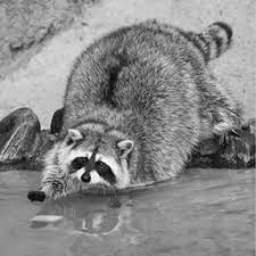

```python
im = Image.fromarray(np.array(dt_mapache, dtype = "uint8"), mode = "L")
im.resize((256,256))
```

## Conclusiones

### En esta practica implementamos un programa en Python para abrir una imagen digital llamada mapache.png. La convertimos en una matriz de pixeles usando numpy y despues mostramos la matriz de la imagen. En la practica tambien cargaramos un archivo mapache.csv y lo convertimos en un DataFrame, posteriormente convertimos el DataFrame en una imagen de 256 x 256 pixeles

## Referencias

### 1. Araujo, SL, Martínez, UR, Rodríguez, AM (2011). Programación y estructuras de datos avanzadas. España: Centro de estudios. Ramón Areces.

### 2. Garrido Carrillo, A. & Valdivia Joaquín, F. (2006). Abstracción y estructura de datos en C++: (ed.). Publicaciones Delta.

### 3. Malik, DS (2013). Estructuras de datos con C++: (2 ed.). Aprendizaje Cengage.

### 4. Google. (2026). Gemini (Versión de agosto de 2026) [Modelo de lenguaje grande]. https://gemini.google.com

### 5. imagenes en python (Pillow, 2026) https://pillow.readthedocs.io/en/stable/ (Ultimo acceso Septiembre de 2026)